# Homework 2

Scott Girten

### Investigating Power

In class, we considered testing the following hypotheses:

$H_0$: population of mpg values is symmetric

$H_a$: population of mpg values is right skewed

In class, we compared a skewness statistic based on cubed z-scores and the ratio of the sample mean to the sample median. However, the statistics below could also be used to test these hypotheses:

- $\frac{Q_3 - \text{Median}}{\text{Median}-Q_1}$
- $\frac{\text{Max}-Q_3}{Q_1 - \text{Min}}$
- $\frac{\text{Median}-Q_1}{Q_3 - Q_1}$
1. Fill in the table below with the value we would expect from each statistic if the population were normally distributed. Briefly explain how you arrived at your answer.

[output not shown]

2. For each statistic, generate the null distribution of the statistic if we sample 25 observations from a normal distribution with a mean of 10 and a standard deviation 2.5. Construct the null distributions based on 10,000 random values from the population. Construct side-by-side histograms of the 3 null distributions.

> T(A) = $\frac{Q_3 - \text{Median}}{\text{Median}-Q_1}$

> T(B) = $\frac{\text{Max}-Q_3}{Q_1 - \text{Min}}$

> T(C) = $\frac{\text{Median}-Q_1}{Q_3 - Q_1}$

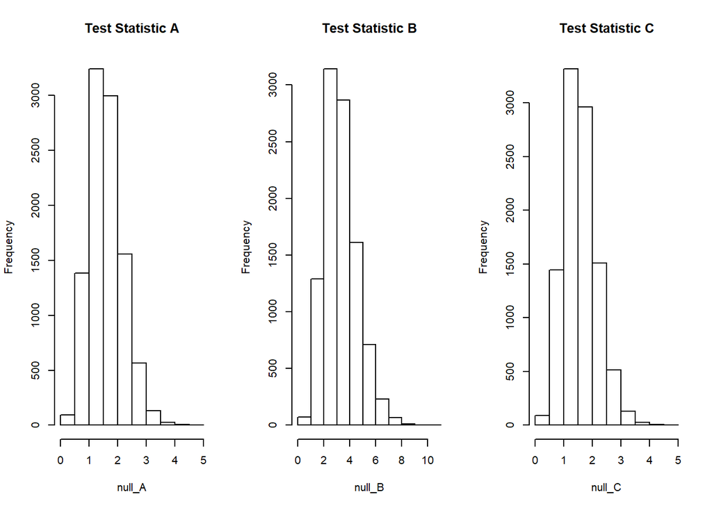

```r
# Create functions for test statistics
ts_A = function(sample_A){
  return(quantile(sample_A, probs =  0.75) - median(sample_A)) / (median(sample_A) - quantile(sample_A, probs = 0.25))
}

ts_B = function(sample_B){
  return(max(sample_B) - quantile(sample_B, probs = 0.75)) / (quantile(sample_B, probs = 0.25) - min(sample_B))
}

ts_C = function(sample_C){
  return(median(sample_C) - quantile(sample_C, probs = 0.25)) / (quantile(sample_C, probs = 0.75) - quantile(sample_C, probs = 0.25))
}

# Population of 10,000 with mean of 10 and standard deviation of 2.5
normal_samples =  replicate(10000, rnorm(25, mean = 10, sd = 2.5))

null_A = apply(normal_samples, 2, ts_A)
null_B = apply(normal_samples, 2, ts_B)
null_C = apply(normal_samples, 2, ts_C)

par(mfrow = c(1, 3))
hist(null_A, main = "Test Statistic A")
hist(null_B, main = "Test Statistic B")
hist(null_C, main = "Test Statistic C")
```

3. To select between these statistics, we would like to choose the statistic which is the most powerful - that is, which statistic is most likely to reject the null hypothesis when the data is actually generated from a right-skewed population. If we simulate from a chi-square distribution with k degrees of freedom, what linear transformation results in data with a mean of 10 and standard deviation of 2.5?

Use the standard deviation to solve for a:

> $Y = aX + b$

> $Var(Y) = a^2Var(X) = 2.5^2$

> $a^2(2k) = 2.5^2$

> $a = \frac{2.5}{\sqrt{2k}}$

Use the mean to solve for b:

> $E(Y) = aE(X) + b = 10$

> $aE(X) + b = 10$

> $\frac{2.5}{\sqrt{2k}}k + b = 10$

The linear transformation that results from a mean of 10 and a standard deviation of 2.5:

> $Y = \frac{2.5}{\sqrt{2k}} + 10 - \frac{2.5}{\sqrt{2k}}$
4. Using the transformation in question 3, simulate random samples of size n = 25 from a chi-square distribution with the following degrees of freedom: 5 and 20. Use the simulated data to determine the power of the proposed test statistics. Include comments in your code that clearly indicate which power value is being calculated (e.g. #Statistic 1, df = 5).

```r
# create vecotrs for test statistics for degrees of freedom of 5 and 20
pvalues_A_df5 = numeric(10000)
pvalues_B_df5 = numeric(10000)
pvalues_C_df5 = numeric(10000)

pvalues_A_df20 = numeric(10000)
pvalues_B_df20 = numeric(10000)
pvalues_C_df20 = numeric(10000)

for (i in 1:10000){
  # Simulate test statistics for degrees of freedom = 5
  sample_df5 = rchisq(25, df = 5)
  sample_df5_trans = 2.5/sqrt(2*5)*sample_df5 + 10 - 2.5/sqrt(2*5)

  # Test statistics A,B and C with df = 5
  ts_A_df5 = ts_A(sample_df5_trans)
  ts_B_df5 = ts_B(sample_df5_trans)
  ts_C_df5 = ts_C(sample_df5_trans)

  pvalues_A_df5[i] = sum(null_A >= ts_A_df5)/10000
  pvalues_B_df5[i] = sum(null_B >= ts_B_df5)/10000
  pvalues_C_df5[i] = sum(null_C >= ts_C_df5)/10000

  # Simulate test statistics for degrees of freedom = 20
  sample_df20 = rchisq(25, df = 20)
  sample_df20_trans = 2.5/sqrt(2*20)*sample_df20 + 10 - 2.5/sqrt(2*20)

  # Test statistics A,B and C for degrees of freedom = 20
  ts_A_df20 = ts_A(sample_df20_trans)
  ts_B_df20 = ts_B(sample_df20_trans)
  ts_C_df20 = ts_C(sample_df20_trans)

  pvalues_A_df20[i] = sum(null_A >= ts_A_df20)/10000
  pvalues_B_df20[i] = sum(null_B >= ts_B_df20)/10000
  pvalues_C_df20[i] = sum(null_C >= ts_C_df20)/10000

}

# Calculate the power for each test statistic and for both degrees of freedom
power_A_df5 = sum(pvalues_A_df5 <= 0.05) / 10000
power_B_df5 = sum(pvalues_B_df5 <= 0.05) / 10000
power_C_df5 = sum(pvalues_C_df5 <= 0.05) / 10000

power_A_df20 = sum(pvalues_A_df20 <= 0.05) / 10000
power_B_df20 = sum(pvalues_B_df20 <= 0.05) / 10000
power_C_df20 = sum(pvalues_C_df20 <= 0.05) / 10000
```

| Test Statistic | df = 5 | df = 20 |
| --- | --- | --- |
| A | 0.0888 | 0.0734 |
| B | 0.3624 | 0.2029 |
| C | 0.0074 | 0.0244 |

5. Now increase your sample size to n = 50 and determine the power. Note - you’ll have to find new null distributions because of the change in sample size. Include comments in your code that clearly indicate which power value is being calculated (e.g. #Statistic 1, df = 5).

```r
# Calculate null distribution for N = 50
normal_samples =  replicate(10000, rnorm(50, mean = 10, sd = 2.5))

null_A2 = apply(normal_samples, 2, ts_A)
null_B2 = apply(normal_samples, 2, ts_B)
null_C2 = apply(normal_samples, 2, ts_C)

# create vecotrs for test statistics for degrees of freedom of 5 and 20
pvalues_A2_df5 = numeric(10000)
pvalues_B2_df5 = numeric(10000)
pvalues_C2_df5 = numeric(10000)

pvalues_A2_df20 = numeric(10000)
pvalues_B2_df20 = numeric(10000)
pvalues_C2_df20 = numeric(10000)

for (i in 1:10000){
  # Simulate test statistics for degrees of freedom = 5
  sample2_df5 = rchisq(50, df = 5)
  sample2_df5_trans = 2.5/sqrt(2*5)*sample2_df5 + 10 - 2.5/sqrt(2*5)

  # Test statistics A,B and C with df = 5
  ts_A2_df5 = ts_A(sample2_df5_trans)
  ts_B2_df5 = ts_B(sample2_df5_trans)
  ts_C2_df5 = ts_C(sample2_df5_trans)

  pvalues_A2_df5[i] = sum(null_A2 >= ts_A2_df5)/10000
  pvalues_B2_df5[i] = sum(null_B2 >= ts_B2_df5)/10000
  pvalues_C2_df5[i] = sum(null_C2 >= ts_C2_df5)/10000

  # Simulate test statistics for degrees of freedom = 20
  sample2_df20 = rchisq(50, df = 20)
  sample2_df20_trans = 2.5/sqrt(2*20)*sample2_df20 + 10 - 2.5/sqrt(2*20)

  # Test statistics A,B and C for degrees of freedom = 20
  ts_A2_df20 = ts_A(sample2_df20_trans)
  ts_B2_df20 = ts_B(sample2_df20_trans)
  ts_C2_df20 = ts_C(sample2_df20_trans)

  pvalues_A2_df20[i] = sum(null_A2 >= ts_A2_df20)/10000
  pvalues_B2_df20[i] = sum(null_B2 >= ts_B2_df20)/10000
  pvalues_C2_df20[i] = sum(null_C2 >= ts_C2_df20)/10000

}

# Calculate the power for each test statistic and for both degrees of freedom
power_A2_df5 = sum(pvalues_A2_df5 <= 0.05) / 10000
power_B2_df5 = sum(pvalues_B2_df5 <= 0.05) / 10000
power_C2_df5 = sum(pvalues_C2_df5 <= 0.05) / 10000

power_A2_df20 = sum(pvalues_A2_df20 <= 0.05) / 10000
power_B2_df20 = sum(pvalues_B2_df20 <= 0.05) / 10000
power_C2_df20 = sum(pvalues_C2_df20 <= 0.05) / 10000
```

| Test Statistic | df = 5 | df = 20 |
| --- | --- | --- |
| A2 | 0.1028 | 0.0824 |
| B2 | 0.5059 | 0.273 |
| C2 | 0.0028 | 0.0185 |

6. Based on your calculations, which statistic of these 3 would you recommend when testing for skewness in a distribution? Explain.

I would use statistic B for testing skewness in a distribution. When considering different degrees of freedom and different sample sizes, statistic B generated the most power of the three statistics under every scenario. Statistic B produced the highest probability for a correct decision - correctly rejecting the null hypothesis when it was false.